# Candidatos a prefeito, doações e doadores

A partir dos dados da prestação de contas das eleições feitas ao Tribunal Superior Eleitoral (TSE) analisamos os dados das doações recebidas por candidatos a prefeitura de Feira de Santana. Apesar de saber que esse ano as doações vindas de empresas não são permitidas, [sabemos que não é o fim delas](https://twitter.com/fecampa/status/1325791183554154498?s=20).

Vale salientar que os dados são atualizados pelo TSE diariamente. Atenção a data que essa análise foi publicada e a data de *download* do arquivo.

### Instruções download dos dados

A análise foi feita com arquivos do [repositório de dados eleitorais do TSE](https://www.tse.jus.br/eleicoes/estatisticas/repositorio-de-dados-eleitorais-1/repositorio-de-dados-eleitorais).

Faça o download do arquivo: https://cdn.tse.jus.br/estatistica/sead/odsele/prestacao_contas/prestacao_de_contas_eleitorais_candidatos_2020.zip (download feito em 16/10/2021)

Siga o seguinte caminho dentro da pasta:

```
Prestação de contas eleitorais > 2020 > Candidatos (formato zip) > receitas_candidatos_2020_BA.csv
```

Copie o arquivo do estado desejado (`receitas_candidatos_2020_<estado>.csv`) para a pasta `analysis` nesse repositório.

Dicionário de dados: `leiame_receitas-candidatos.pdf`

Observações sobre os dados:

- `#NULO` é o mesmo que `None` ou vazio
- `#NE` significa que naquele ano a informação não era registrada
- Campo `UF`: `BR` para nível nacional, `VT` voto em trânsito e `ZZ` para Exterior
- Campo `NM_UE`, no caso de eleições municipais, é o nome do município

```python
import pandas as pd
from scripts.parsers import currency_to_float, is_company


df = pd.read_csv("receitas_candidatos_2020_BA-16.10.2020.csv", encoding="latin", delimiter=";")
```

```python
pd.set_option('display.max_rows', None)
```

```python
import seaborn as sns
import matplotlib.pyplot as plt
```

```python
df_feira = df[df["NM_UE"] == "FEIRA DE SANTANA"].copy()
```

```python
df_feira["VR_RECEITA"] = df_feira["VR_RECEITA"].apply(currency_to_float)
```

```python
fields = [
    "NM_CANDIDATO", "SG_PARTIDO", "DS_FONTE_RECEITA", "DS_ORIGEM_RECEITA",
    "NR_CPF_CNPJ_DOADOR", "NM_DOADOR", "NM_DOADOR_RFB", "DS_CARGO",
    "NM_MUNICIPIO_DOADOR", "NM_PARTIDO_DOADOR", "DT_RECEITA", "DS_RECEITA", "VR_RECEITA",
]

df_filtered = df_feira[fields]
```

Para melhorar a experiência das pessoas na visualização dos dados vamos substituir o valor "#NULO#" por vazio.

```python
df_filtered = df_filtered.replace("#NULO#", "").copy()
df_filtered[df_filtered["NM_PARTIDO_DOADOR"] == "#NULO#"]
```

|  | NM_CANDIDATO | SG_PARTIDO | DS_FONTE_RECEITA | DS_ORIGEM_RECEITA | NR_CPF_CNPJ_DOADOR | NM_DOADOR | NM_DOADOR_RFB | DS_CARGO | NM_MUNICIPIO_DOADOR | NM_PARTIDO_DOADOR | DT_RECEITA | DS_RECEITA | VR_RECEITA |
| --- | --- | --- | --- | --- | --- | --- | --- | --- | --- | --- | --- | --- | --- |

## Doações recebidas por candidatos a prefeito

Vamos filtrar as doações feitas para prefeitos. Ao final dessa página você poderá ver a lista com todos as doações recebidas pelos candidatos a prefeito na cidade de Feira de Santana.

Abaixo uma amostra aleatória de 5 doações recebidas:

```python
mayor_df = df_filtered[df_filtered["DS_CARGO"] == "Prefeito"]
mayor_df.sample(5)  # amostra das doações a prefeitos de Feira de Santana
```

|  | NM_CANDIDATO | SG_PARTIDO | DS_FONTE_RECEITA | DS_ORIGEM_RECEITA | NR_CPF_CNPJ_DOADOR | NM_DOADOR | NM_DOADOR_RFB | DS_CARGO | NM_MUNICIPIO_DOADOR | NM_PARTIDO_DOADOR | DT_RECEITA | DS_RECEITA | VR_RECEITA |
| --- | --- | --- | --- | --- | --- | --- | --- | --- | --- | --- | --- | --- | --- |
| 58760 | CARLOS MEDEIROS MIRANDA | NOVO | Outros Recursos | Recursos de pessoas físicas | 16025913854 | MAICON AMERICO COELHO MORAES | MAICON AMERICO COELHO MORAES | Prefeito |  |  | 16/11/2020 |  | 200.0 |
| 35554 | JOSE CERQUEIRA DE SANTANA NETO | PT | Outros Recursos | Recursos próprios | 63674815591 | ROQUE EUDES SOUZA DOS SANTOS | ROQUE EUDES SOUZA DOS SANTOS | Prefeito | FEIRA DE SANTANA | Partido dos Trabalhadores | 06/11/2020 |  | 20000.0 |
| 80375 | CARLOS MEDEIROS MIRANDA | NOVO | Outros Recursos | Recursos de pessoas físicas | 82589801734 | MARCELO RUCKER | MARCELO RUCKER | Prefeito |  |  | 16/11/2020 |  | 200.0 |
| 53429 | COLBERT MARTINS DA SILVA FILHO | MDB | Outros Recursos | Recursos de pessoas físicas | 25725114520 | JOSÉ MARCONE DE CARVALHO | JOSE MARCONDES DE CARVALHO | Prefeito |  |  | 30/10/2020 |  | 3000.0 |
| 116948 | MARCELA PREST | PSOL | Outros Recursos | Recursos de pessoas físicas | 3258451583 | DAVI MENDES LEITE | DAVI MENDES LEITE | Prefeito |  |  | 08/10/2020 |  | 100.0 |

### Total, mediana e número de doações recebidas por candidato

```python
statistics = mayor_df.groupby(
    ["NM_CANDIDATO"]
)["VR_RECEITA"].agg(["sum", "median", "count"]).sort_values(ascending=False, by=["sum", "NM_CANDIDATO"])
statistics
```

| NM_CANDIDATO | sum | median | count |
| --- | --- | --- | --- |
| JOSE CERQUEIRA DE SANTANA NETO | 2533678.67 | 14875.125 | 30 |
| DAYANE JAMILLE CARNEIRO DOS SANTOS PIMENTEL | 1808167.86 | 323167.860 | 5 |
| COLBERT MARTINS DA SILVA FILHO | 1233951.50 | 6000.000 | 31 |
| JOSE DE ARIMATEIA CORIOLANO DE PAIVA | 192780.00 | 3000.000 | 13 |
| CARLOS GEILSON DOS SANTOS SILVA | 153000.00 | 50000.000 | 3 |
| CARLOS MEDEIROS MIRANDA | 83865.34 | 200.000 | 72 |
| MARCELA PREST | 39069.00 | 1020.000 | 19 |
| ROBERTO LUIS DA SILVA TOURINHO | 25290.00 | 5000.000 | 4 |
| ORLANDO ANDRADE DE JESUS | 1000.00 | 500.000 | 2 |

```
(array([-500000.,       0.,  500000., 1000000., 1500000., 2000000.,
        2500000., 3000000.]),
 [Text(0, 0, ''),
```

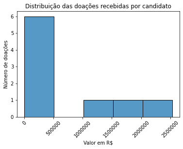

```python
ax = sns.histplot(data=statistics, x="sum")
ax.set_xlabel("Valor em R$")
ax.set_ylabel("Número de doações")
ax.set_title("Distribuição das doações recebidas por candidato")
ax.xaxis.get_major_formatter().set_scientific(False)
plt.xticks(rotation=45)
```

```
(array([      0.,  500000., 1000000., 1500000., 2000000., 2500000.,
        3000000.]),
 [Text(0, 0, ''),
```

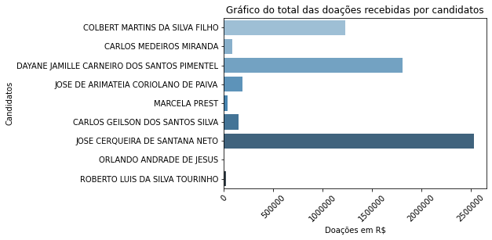

```python
ax = sns.barplot(x="VR_RECEITA", y="NM_CANDIDATO", data=mayor_df, palette="Blues_d", ci=None, estimator=sum)
ax.set_xlabel("Doações em R$")
ax.set_ylabel("Candidatos")
ax.set_title("Gráfico do total das doações recebidas por candidatos")
ax.xaxis.get_major_formatter().set_scientific(False)
plt.xticks(rotation=45)
```

## Quem são os doadores?

```python
mayor_df.groupby(
    ["NM_CANDIDATO", "NM_DOADOR_RFB", "NR_CPF_CNPJ_DOADOR", "NM_PARTIDO_DOADOR", "NM_MUNICIPIO_DOADOR"]
)["VR_RECEITA"].agg(["sum"])
```

| NM_CANDIDATO | NM_DOADOR_RFB | NR_CPF_CNPJ_DOADOR | NM_PARTIDO_DOADOR | NM_MUNICIPIO_DOADOR | sum |
| --- | --- | --- | --- | --- | --- |
| CARLOS GEILSON DOS SANTOS SILVA | CARLOS GEILSON DOS SANTOS SILVA | 22475532572 | Podemos | FEIRA DE SANTANA | 50000.00 |
|  | ESAU THIAGO SANTANA SILVA | 2881980503 |  |  | 3000.00 |
|  | PODEMOS | 4078889000180 | Podemos |  | 100000.00 |
| CARLOS MEDEIROS MIRANDA | ADRIANA PORTUGAL BRITO | 60657995568 |  |  | 3000.00 |
|  | ALEXANDRE MAGNO FRANCA REIS | 89193857691 |  |  | 200.00 |
|  | AMILTON DE ALMEIDA SAMPAIO JUNIOR | 64835103572 |  |  | 500.00 |
|  | ANDERSON OLINTO DO BU | 2564836470 |  |  | 600.00 |
|  | BRUNO CYRENO TAVARES DE SOUZA | 86414267449 |  |  | 200.00 |
|  | CAIO MARTINS FONTE PEREIRA | 16324906841 |  |  | 200.01 |
|  | CARLOS EDUARDO CAVALCANTI VIEIRA | 126858799 |  |  | 100.00 |
|  | CARLOS MEDEIROS MIRANDA | 70580960587 | Partido Novo | FEIRA DE SANTANA | 15700.00 |
|  | CARLOS VINICIUS DE SA RORIZ | 90563344768 |  |  | 200.00 |
|  | CLAUDIA ELISA DE PINHO SOARES | 563928778 |  |  | 200.00 |
|  | CLAUDIO JOSE RIBEIRO SILVA | 21065985568 |  |  | 5500.00 |
|  | CRISTIAN GIOVANI BONEZZI | 1592667937 |  |  | 200.00 |
|  | DANILLO GARGANO FIGUEIREDO | 11047921847 |  |  | 200.00 |
|  | DILMA ALMEIDA PORTUGAL | 14061384520 |  |  | 3000.00 |
|  | EDUARDO HENRIQUE SOUZA DE FRANCA | 62042084468 |  |  | 100.00 |
|  | FERNANDO TONELLI BERGARO | 29254134805 |  |  | 200.00 |
|  | FLAVIO ROQUE GARCIA SILVA | 11785367854 |  |  | 200.00 |
|  | FREDERICO JORGE DE SOUSA BOABAID | 3302440782 |  |  | 400.00 |
|  | GUSTAVO FIGUEIRA DE ALMEIDA E ALBUQUERQUE | 428107796 |  |  | 200.00 |
|  | GUSTAVO VASCONCELLOS PEREIRA | 72350628 |  |  | 100.00 |
|  | HENRIQUE MENDES JUNIOR | 2563864712 |  |  | 200.00 |
|  | HOMERO DE CARVALHO BASTOS | 49054783168 |  |  | 200.00 |
|  | JANIO OLIVEIRA LIMA | 41945905549 |  |  | 500.00 |
|  | JOSE ALEXANDRE COBRA | 63921880610 |  |  | 200.00 |
|  | JOSE ANTONIO BACELLAR GONCALVES TOURINHO | 24109282500 |  |  | 100.00 |
|  | JOSE CARLOS DE MOURA BEZERRIL FILHO | 2495610420 |  |  | 500.00 |
|  | JOSE MARIO TEIXEIRA PORTELA RIBEIRO | 726147818 |  |  | 200.00 |

[output cut: 78 more lines]

### Qual a origem dos recursos?

```
[Text(0, 0, 'COLBERT MARTINS DA SILVA FILHO'),
```

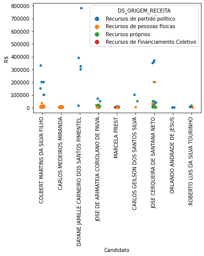

```python
ax = sns.stripplot(x="NM_CANDIDATO", y="VR_RECEITA", hue="DS_ORIGEM_RECEITA", data=mayor_df)

ax.set_xlabel("Candidato")
ax.set_ylabel("R$")
ax.set_xticklabels(ax.get_xticklabels(), rotation=90)
```

Entre os candidatos podemos ver diferenças na distribuição da origem das receitas.

O candidato CARLOS MEDEIROS MIRANDA (Novo) recebeu doações diversificadas de pessoas físicas. Enquanto DAYANE JAMILLE CARNEIRO DOS SANTOS PIMENTEL recebeu massivamente doações vindas do seu partido (PSL), tudo indica que graças ao fundão eleitoral ([o PSL recebeu o segundo maior montante dessas eleições, com cerca de 199 milhões de reais](https://www.tse.jus.br/imprensa/noticias-tse/2020/Junho/divulgada-nova-tabela-com-a-divisao-dos-recursos-do-fundo-eleitoral-para-2020)).

A candidata que se destacou no recebimento de recursos de financiamento coletivo, modalidade que ainda não é muito popular dentre os outros candidatos, foi a MARCELA PREST (PSOL).

### Veja os valores por candidato e origem

```python
mayor_df.groupby(["NM_CANDIDATO", "DS_ORIGEM_RECEITA"])["VR_RECEITA"].agg(["sum"])
```

| NM_CANDIDATO | DS_ORIGEM_RECEITA | sum |
| --- | --- | --- |
| CARLOS GEILSON DOS SANTOS SILVA | Recursos de partido político | 100000.00 |
|  | Recursos de pessoas físicas | 3000.00 |
|  | Recursos próprios | 50000.00 |
| CARLOS MEDEIROS MIRANDA | Recursos de Financiamento Coletivo | 4600.00 |
|  | Recursos de partido político | 3210.33 |
|  | Recursos de pessoas físicas | 60355.01 |
|  | Recursos próprios | 15700.00 |
| COLBERT MARTINS DA SILVA FILHO | Recursos de partido político | 1080000.00 |
|  | Recursos de pessoas físicas | 150251.50 |
|  | Recursos próprios | 3700.00 |
| DAYANE JAMILLE CARNEIRO DOS SANTOS PIMENTEL | Recursos de partido político | 1808167.86 |
| JOSE CERQUEIRA DE SANTANA NETO | Recursos de partido político | 2178231.46 |
|  | Recursos de pessoas físicas | 259447.21 |
|  | Recursos próprios | 96000.00 |
| JOSE DE ARIMATEIA CORIOLANO DE PAIVA | Recursos de partido político | 120000.00 |
|  | Recursos de pessoas físicas | 3180.00 |
|  | Recursos próprios | 69600.00 |
| MARCELA PREST | Recursos de Financiamento Coletivo | 8689.00 |
|  | Recursos de partido político | 29870.00 |
|  | Recursos de pessoas físicas | 510.00 |
| ORLANDO ANDRADE DE JESUS | Recursos de partido político | 1000.00 |
| ROBERTO LUIS DA SILVA TOURINHO | Recursos de partido político | 10000.00 |
|  | Recursos de pessoas físicas | 150.00 |
|  | Recursos próprios | 15140.00 |

## Ranking de Doadores

```python
mayor_df.groupby(["NM_DOADOR_RFB", "NM_DOADOR"])["VR_RECEITA"].agg(
    ["sum"]
).sort_values(ascending=False, by=["sum", "NM_DOADOR_RFB"])
```

| NM_DOADOR_RFB | NM_DOADOR | sum |
| --- | --- | --- |
| PARTIDO SOCIAL LIBERAL | Direção Nacional | 1493167.86 |
| PARTIDO DOS TRABALHADORES | Direção Estadual/Distrital | 1334974.32 |
|  | Direção Nacional | 803257.14 |
| DEMOCRATAS - DIRETORIO NACIONAL | Direção Nacional | 730000.00 |
| MOVIMENTO DEMOCRATICO BRASILEIRO - BRASIL - BR - NACIONAL | Direção Nacional | 350000.00 |
| PSL - PARTIDO SOCIAL LIBERAL COMISSAO PROVISORIA | Direção Municipal/Comissão Provisória | 315000.00 |
| LUTZ VIANA RODRIGUES JUNIOR | LUTZ VIANA RODRIGUES JUNIOR | 200000.00 |
| REPUBLICANOS - BAHIA - ESTADUAL | Direção Estadual/Distrital | 120000.00 |
| PODEMOS | Direção Estadual/Distrital | 100000.00 |
| JOSE CERQUEIRA DE SANTANA NETO | JOSE CERQUEIRA DE SANTANA NETO | 76000.00 |
| JOSE DE ARIMATEIA CORIOLANO DE PAIVA | JOSE DE ARIMATEIA CORIOLANO DE PAIVA | 69600.00 |
| CARLOS GEILSON DOS SANTOS SILVA | CARLOS GEILSON SANTOS SILVA | 50000.00 |
| PARTIDO PROGRESSISTA - PP | Direção Estadual/Distrital | 40000.00 |
| ANTONIO SANTOS FILGUEIRAS | ANTONIO SANTOS FILGUEIRAS | 40000.00 |
| MARGARETH IRACEMA HUFNAGEL MARTINEZ FALCAO | MARGARETH IRACEMA HUFNAGEL M FALCÃO | 35000.00 |
| COMISSAO PROVISORIA DO PARTIDO SOCIALISMO E LIBERDADE - PSOL | Direção Municipal/Comissão Provisória | 29870.00 |
| JOAO MARCELO AZEVEDO GOMES | JOÃO MARCELO AZEVEDO GOMES | 21720.00 |
| ROQUE EUDES SOUZA DOS SANTOS | ROQUE EUDES SOUZA DOS SANTOS | 20000.00 |
| LUIZ FERNANDO LUZ PESSOA DE SOUZA | LUIZ FERNANDO LUZ PESSOA DE SOUZA | 19750.00 |
| CARLOS MEDEIROS MIRANDA | CARLOS MEDEIROS MIRANDA | 15700.00 |
| ROBERTO LUIS DA SILVA TOURINHO | ROBERTO LUIS DA SILVA TOURINHO | 15140.00 |
| ADENILDA LIMA LOPES MARTINS | ADENILDA LIMA LOPES MARTINS | 15000.00 |
| CORIOLANO CARVALHO MARTINS | CORIOLANO CARVALHO MARTINS | 14000.00 |
| WILSON FERREIRA FALCAO | WILSON FERREIRA FALCÃO | 12000.00 |
| VALFREDO NOVAIS SILVA | VALFREDO | 11560.00 |
| PEDRO FALCAO VIEIRA NETO | PEDRO FALCAO VIEIRA NETO | 11045.00 |
| WILSON DOS SANTOS MOTA | WILSON DOS SANTOS MOTA | 10000.00 |
| PARTIDO SOCIALISTA BRASILEIRO-FEIRA DE SANTANA-BA-MUNICIPAL | Direção Municipal/Comissão Provisória | 10000.00 |
| EUNAPIO LADEIA DE QUEIROZ | EUNAPIO LADEIA DE QUEIROZ | 10000.00 |
| DENILTON PEREIRA DE BRITO | DENILTON PEREIRA DE BRITO | 9000.00 |

[output cut: 77 more lines]

## As pessoas que doaram estão ligadas a empresas diretamente?

```python
def mask_cpf(cpf):
    """Útil para busca dos sócios em empresas no Brasil.io."""
    cpf = str(cpf)
    return f"***{cpf[3:9]}**"


mayor_df_copy = mayor_df.copy()
mayor_df_copy["DONATED_BY_CNPJ"] = mayor_df_copy["NR_CPF_CNPJ_DOADOR"].apply(is_company)

donated_by_people = mayor_df_copy[mayor_df_copy["DONATED_BY_CNPJ"] == False]
donated_by_people = donated_by_people[donated_by_people["NM_CANDIDATO"] != donated_by_people["NM_DOADOR_RFB"]]
donated_by_people["CPF_MASCARADO"] = mayor_df_copy["NR_CPF_CNPJ_DOADOR"].apply(mask_cpf)
donated_by_people[["NM_CANDIDATO", "NM_DOADOR_RFB", "NR_CPF_CNPJ_DOADOR", "CPF_MASCARADO"]]
```

|  | NM_CANDIDATO | NM_DOADOR_RFB | NR_CPF_CNPJ_DOADOR | CPF_MASCARADO |
| --- | --- | --- | --- | --- |
| 3665 | CARLOS MEDEIROS MIRANDA | BRUNO CYRENO TAVARES DE SOUZA | 86414267449 | ***142674** |
| 4840 | COLBERT MARTINS DA SILVA FILHO | JOSE ALBERTO SOUZA E SILVA JUNIOR | 51562260510 | ***622605** |
| 7804 | CARLOS MEDEIROS MIRANDA | STELLA CALDEIRA BRANT RODRIGUES ALVES | 91056144653 | ***561446** |
| 14396 | CARLOS MEDEIROS MIRANDA | PEDRO OLIMPIO DA SILVA MACIEL | 36373966615 | ***739666** |
| 14696 | CARLOS MEDEIROS MIRANDA | RONIE WISTON CORDEIRO GUIMARAES | 95993258691 | ***932586** |
| 20708 | CARLOS MEDEIROS MIRANDA | LUCIANO KLIEMASCHEWSK MARINHO | 82834105120 | ***341051** |
| 25736 | CARLOS MEDEIROS MIRANDA | JULIANO PIRES GODOY | 96149400697 | ***494006** |
| 25965 | CARLOS MEDEIROS MIRANDA | AMILTON DE ALMEIDA SAMPAIO JUNIOR | 64835103572 | ***351035** |
| 25966 | CARLOS MEDEIROS MIRANDA | LUIS RICARDO YAMANISHI | 14823097858 | ***230978** |
| 25967 | CARLOS MEDEIROS MIRANDA | LUIZ ALEXANDRE ALVES SOARES CALMONT FRANCISS | 40618409831 | ***184098** |
| 28220 | CARLOS MEDEIROS MIRANDA | MAURICIO JOSE PEDROSA MALTA FILHO | 93935250487 | ***352504** |
| 28221 | CARLOS MEDEIROS MIRANDA | MAURICIO JOSE PEDROSA MALTA FILHO | 93935250487 | ***352504** |
| 33590 | CARLOS MEDEIROS MIRANDA | VINICIUS GUIMARAES BARBOSA | 95693181715 | ***931817** |
| 33619 | CARLOS MEDEIROS MIRANDA | VALDECIR ROBERTO BECHEL | 58530339991 | ***303399** |
| 33620 | CARLOS MEDEIROS MIRANDA | VALDECIR ROBERTO BECHEL | 58530339991 | ***303399** |
| 35024 | CARLOS MEDEIROS MIRANDA | FLAVIO ROQUE GARCIA SILVA | 11785367854 | ***853678** |
| 35554 | JOSE CERQUEIRA DE SANTANA NETO | ROQUE EUDES SOUZA DOS SANTOS | 63674815591 | ***748155** |
| 39158 | CARLOS MEDEIROS MIRANDA | DILMA ALMEIDA PORTUGAL | 14061384520 | ***613845** |
| 44141 | CARLOS MEDEIROS MIRANDA | SANDRO LEITE FERREIRA | 77936752153 | ***367521** |
| 44142 | CARLOS MEDEIROS MIRANDA | HOMERO DE CARVALHO BASTOS | 49054783168 | ***547831** |
| 44143 | CARLOS MEDEIROS MIRANDA | SILVIO JOSE MORAIS | 45037990963 | ***379909** |
| 44144 | CARLOS MEDEIROS MIRANDA | ALEXANDRE MAGNO FRANCA REIS | 89193857691 | ***938576** |
| 44145 | CARLOS MEDEIROS MIRANDA | LEONARDO PRAZERES ALVES | 76992926500 | ***929265** |
| 48780 | CARLOS MEDEIROS MIRANDA | MARCELO AMARANTE DE SOUZA CARVALHO | 87361515720 | ***615157** |
| 52396 | CARLOS MEDEIROS MIRANDA | PABIO VINICIO ANDRADE | 61402931549 | ***029315** |
| 52397 | CARLOS MEDEIROS MIRANDA | EDUARDO HENRIQUE SOUZA DE FRANCA | 62042084468 | ***420844** |
| 52800 | ROBERTO LUIS DA SILVA TOURINHO | ANDREA MATOS DA SILVA TOURINHO | 68702949504 | ***029495** |
| 53429 | COLBERT MARTINS DA SILVA FILHO | JOSE MARCONDES DE CARVALHO | 25725114520 | ***251145** |
| 54236 | CARLOS MEDEIROS MIRANDA | CAIO MARTINS FONTE PEREIRA | 16324906841 | ***249068** |
| 54474 | CARLOS MEDEIROS MIRANDA | DANILLO GARGANO FIGUEIREDO | 11047921847 | ***479218** |
| 54475 | CARLOS MEDEIROS MIRANDA | MARIA FERNANDA DA SILVA VILARINHO SIMOES DE AL... | 29305639828 | ***056398** |
| 54476 | CARLOS MEDEIROS MIRANDA | RODOLFO BERNARDES ROQUETTE | 35480513168 | ***805131** |
| 57401 | CARLOS MEDEIROS MIRANDA | JOSE ANTONIO BACELLAR GONCALVES TOURINHO | 24109282500 | ***092825** |
| 57403 | CARLOS MEDEIROS MIRANDA | LUIZ CARLOS SICILIANO | 78962242753 | ***622427** |
| 57961 | COLBERT MARTINS DA SILVA FILHO | WILSON DOS SANTOS MOTA | 27138887515 | ***388875** |
| 58750 | CARLOS MEDEIROS MIRANDA | FERNANDO TONELLI BERGARO | 29254134805 | ***541348** |
| 58760 | CARLOS MEDEIROS MIRANDA | MAICON AMERICO COELHO MORAES | 16025913854 | ***259138** |
| 59525 | COLBERT MARTINS DA SILVA FILHO | WILSON FERREIRA FALCAO | 19309287500 | ***092875** |
| 65834 | COLBERT MARTINS DA SILVA FILHO | JAILSON RODRIGUES DUARTE | 40316734500 | ***167345** |
| 65835 | COLBERT MARTINS DA SILVA FILHO | MARGARETH IRACEMA HUFNAGEL MARTINEZ FALCAO | 48786802534 | ***868025** |
| 67040 | CARLOS MEDEIROS MIRANDA | RICARDO BACELLAR WUERKERT | 76759873734 | ***598737** |
| 67798 | JOSE CERQUEIRA DE SANTANA NETO | NAIANA DOS SANTOS SOUZA SANTANA | 95027580568 | ***275805** |
| 74398 | COLBERT MARTINS DA SILVA FILHO | DENILTON PEREIRA DE BRITO | 28075102568 | ***751025** |
| 78738 | CARLOS MEDEIROS MIRANDA | JANIO OLIVEIRA LIMA | 41945905549 | ***459055** |
| 80375 | CARLOS MEDEIROS MIRANDA | MARCELO RUCKER | 82589801734 | ***898017** |
| 80851 | CARLOS MEDEIROS MIRANDA | SERGIO ALEXANDRE USTULIN | 13079002830 | ***790028** |
| 80852 | CARLOS MEDEIROS MIRANDA | SERGIO ALEXANDRE USTULIN | 13079002830 | ***790028** |
| 82753 | CARLOS MEDEIROS MIRANDA | ROMULO ASSUNCAO SOARES DE AVELLAR | 74854852453 | ***548524** |
| 91507 | CARLOS MEDEIROS MIRANDA | VALFREDO NOVAIS SILVA | 36089257591 | ***892575** |
| 98218 | CARLOS MEDEIROS MIRANDA | SERGIO SARAIVA CASTELO BRANCO DE PONTES | 41672690153 | ***726901** |
| 103858 | CARLOS MEDEIROS MIRANDA | OSMAR BARBOSA CAMPOS | 89183320768 | ***833207** |
| 103893 | CARLOS MEDEIROS MIRANDA | ADRIANA PORTUGAL BRITO | 60657995568 | ***579955** |
| 105908 | CARLOS MEDEIROS MIRANDA | LUCAS BERENGUER REGIS | 88636747520 | ***367475** |
| 108751 | JOSE CERQUEIRA DE SANTANA NETO | EDILMA DOS REIS SILVA | 21378134591 | ***781345** |
| 110559 | COLBERT MARTINS DA SILVA FILHO | CORIOLANO CARVALHO MARTINS | 94223785591 | ***237855** |
| 110560 | COLBERT MARTINS DA SILVA FILHO | JOAO MARCELO AZEVEDO GOMES | 52793354520 | ***933545** |
| 110561 | COLBERT MARTINS DA SILVA FILHO | JOAO MARCELO AZEVEDO GOMES | 52793354520 | ***933545** |
| 110562 | COLBERT MARTINS DA SILVA FILHO | JOAO MARCELO AZEVEDO GOMES | 52793354520 | ***933545** |
| 110563 | COLBERT MARTINS DA SILVA FILHO | JOAO MARCELO AZEVEDO GOMES | 52793354520 | ***933545** |
| 110564 | COLBERT MARTINS DA SILVA FILHO | JOAO MARCELO AZEVEDO GOMES | 52793354520 | ***933545** |
| 110565 | COLBERT MARTINS DA SILVA FILHO | JOAO MARCELO AZEVEDO GOMES | 52793354520 | ***933545** |
| 110566 | COLBERT MARTINS DA SILVA FILHO | JOAO MARCELO AZEVEDO GOMES | 52793354520 | ***933545** |
| 110568 | COLBERT MARTINS DA SILVA FILHO | JOAO MARCELO AZEVEDO GOMES | 52793354520 | ***933545** |
| 110569 | COLBERT MARTINS DA SILVA FILHO | VALDEMIR SILVA BASTOS | 41420110578 | ***201105** |
| 110686 | COLBERT MARTINS DA SILVA FILHO | ADENILDA LIMA LOPES MARTINS | 13082841520 | ***828415** |
| 112289 | CARLOS MEDEIROS MIRANDA | CLAUDIO JOSE RIBEIRO SILVA | 21065985568 | ***659855** |
| 112290 | CARLOS MEDEIROS MIRANDA | RAFAEL IVANISK OLIVEIRA | 51293420549 | ***934205** |
| 112291 | CARLOS MEDEIROS MIRANDA | CLAUDIO JOSE RIBEIRO SILVA | 21065985568 | ***659855** |
| 112292 | CARLOS MEDEIROS MIRANDA | CARLOS VINICIUS DE SA RORIZ | 90563344768 | ***633447** |
| 112293 | CARLOS MEDEIROS MIRANDA | JOSE ALEXANDRE COBRA | 63921880610 | ***218806** |
| 116759 | MARCELA PREST | JOSE CARLOS BARRETO DE SANTANA | 11100656553 | ***006565** |
| 116766 | MARCELA PREST | JANIO LAURENTINO DE JESUS SANTOS | 76968049520 | ***680495** |
| 116990 | CARLOS MEDEIROS MIRANDA | PEDRO FALCAO VIEIRA NETO | 97356808587 | ***568085** |
| 116991 | CARLOS MEDEIROS MIRANDA | PEDRO FALCAO VIEIRA NETO | 97356808587 | ***568085** |
| 116992 | CARLOS MEDEIROS MIRANDA | PEDRO FALCAO VIEIRA NETO | 97356808587 | ***568085** |
| 118897 | JOSE CERQUEIRA DE SANTANA NETO | LUTZ VIANA RODRIGUES JUNIOR | 34814396600 | ***143966** |

Para verificar se os doadores são sócios em empresas, basta acessar https://brasil.io/dataset/socios-brasil/socios/ e buscar pelo nome completo e CPF mascarado campos `Nome/Razão Social do Sócio` e `CPF/CNPJ do Sócio`.

Para confirmar as informações, verifique se o CPF mascarado que você buscou bate com o CPF mostrado e com o nome completo da página para confirmar.

Exemplo:

https://brasil.io/dataset/socios-brasil/socios/?search=&cnpj=&razao_social=&cpf_cnpj_socio=***092875**&nome_socio=WILSON+FERREIRA+FALCAO&tipo_socio=&qualificacao_socio=

## Qual partido é mais generoso?

As doações feitas por partidas podem ser identificadas pela coluna `NM_PARTIDO_DOADOR`. O valor `#NULO#` representa as doações feitas por todas as outras entidades que não são partidos (como pessoas e aplicativos de doação).

```python
donations_by_party = mayor_df[mayor_df["NM_PARTIDO_DOADOR"] != ""].groupby(
    ["NM_PARTIDO_DOADOR"], as_index=False
)["VR_RECEITA"].agg({"Total": sum}).sort_values(
    ascending=False, by=["Total", "NM_PARTIDO_DOADOR"]
)
donations_by_party
```

|  | NM_PARTIDO_DOADOR | Total |
| --- | --- | --- |
| 8 | Partido dos Trabalhadores | 2234231.46 |
| 4 | Partido Social Liberal | 1808167.86 |
| 0 | Democratas | 730000.00 |
| 1 | Movimento Democrático Brasileiro | 353700.00 |
| 10 | REPUBLICANOS | 189600.00 |
| 9 | Podemos | 150000.00 |
| 2 | PROGRESSISTAS | 40000.00 |
| 5 | Partido Socialismo e Liberdade | 29870.00 |
| 6 | Partido Socialista Brasileiro | 25140.00 |
| 3 | Partido Novo | 18910.33 |
| 7 | Partido da Causa Operária | 1000.00 |

```
(array([      0.,  500000., 1000000., 1500000., 2000000., 2500000.]),
 [Text(0, 0, ''),
```

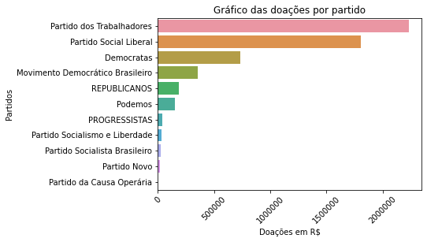

```python
ax = sns.barplot(x="Total", y="NM_PARTIDO_DOADOR", data=donations_by_party, ci=None, estimator=sum)
ax.set_xlabel("Doações em R$")
ax.set_ylabel("Partidos")
ax.set_title("Gráfico das doações por partido")
ax.xaxis.get_major_formatter().set_scientific(False)
plt.xticks(rotation=45)
```

## Veja todas as doações

```python
mayor_df
```

|  | NM_CANDIDATO | SG_PARTIDO | DS_FONTE_RECEITA | DS_ORIGEM_RECEITA | NR_CPF_CNPJ_DOADOR | NM_DOADOR | NM_DOADOR_RFB | DS_CARGO | NM_MUNICIPIO_DOADOR | NM_PARTIDO_DOADOR | DT_RECEITA | DS_RECEITA | VR_RECEITA |
| --- | --- | --- | --- | --- | --- | --- | --- | --- | --- | --- | --- | --- | --- |
| 46 | COLBERT MARTINS DA SILVA FILHO | MDB | Fundo Especial | Recursos de partido político | 1633510000169 | Direção Nacional | DEMOCRATAS - DIRETORIO NACIONAL | Prefeito |  | Democratas | 19/11/2020 |  | 200000.00 |
| 47 | COLBERT MARTINS DA SILVA FILHO | MDB | Fundo Especial | Recursos de partido político | 1633510000169 | Direção Nacional | DEMOCRATAS - DIRETORIO NACIONAL | Prefeito |  | Democratas | 16/10/2020 |  | 100000.00 |
| 48 | COLBERT MARTINS DA SILVA FILHO | MDB | Fundo Especial | Recursos de partido político | 1633510000169 | Direção Nacional | DEMOCRATAS - DIRETORIO NACIONAL | Prefeito |  | Democratas | 28/10/2020 |  | 100000.00 |
| 49 | COLBERT MARTINS DA SILVA FILHO | MDB | Fundo Especial | Recursos de partido político | 1633510000169 | Direção Nacional | DEMOCRATAS - DIRETORIO NACIONAL | Prefeito |  | Democratas | 03/11/2020 |  | 330000.00 |
| 1257 | CARLOS MEDEIROS MIRANDA | NOVO | Outros Recursos | Recursos de pessoas físicas | 72350628 | GUSTAVO VASCON | GUSTAVO VASCONCELLOS PEREIRA | Prefeito |  |  | 16/11/2020 |  | 100.00 |
| 3665 | CARLOS MEDEIROS MIRANDA | NOVO | Outros Recursos | Recursos de pessoas físicas | 86414267449 | BRUNO CYRENO TAVARES DE SOUZA | BRUNO CYRENO TAVARES DE SOUZA | Prefeito |  |  | 16/11/2020 |  | 200.00 |
| 4232 | DAYANE JAMILLE CARNEIRO DOS SANTOS PIMENTEL | PSL | Fundo Especial | Recursos de partido político | 1209414000198 | Direção Nacional | PARTIDO SOCIAL LIBERAL | Prefeito |  | Partido Social Liberal | 08/10/2020 |  | 390000.00 |
| 4233 | DAYANE JAMILLE CARNEIRO DOS SANTOS PIMENTEL | PSL | Fundo Especial | Recursos de partido político | 1209414000198 | Direção Nacional | PARTIDO SOCIAL LIBERAL | Prefeito |  | Partido Social Liberal | 09/11/2020 |  | 323167.86 |
| 4234 | DAYANE JAMILLE CARNEIRO DOS SANTOS PIMENTEL | PSL | Fundo Especial | Recursos de partido político | 1209414000198 | Direção Nacional | PARTIDO SOCIAL LIBERAL | Prefeito |  | Partido Social Liberal | 29/10/2020 |  | 780000.00 |
| 4840 | COLBERT MARTINS DA SILVA FILHO | MDB | Outros Recursos | Recursos de pessoas físicas | 51562260510 | JOSÉ ALBERTO S SILVA JR | JOSE ALBERTO SOUZA E SILVA JUNIOR | Prefeito |  |  | 10/12/2020 |  | 510.00 |
| 7804 | CARLOS MEDEIROS MIRANDA | NOVO | Outros Recursos | Recursos de pessoas físicas | 91056144653 | STELLA MATA MACHADO CALDEIRA BRANT | STELLA CALDEIRA BRANT RODRIGUES ALVES | Prefeito |  |  | 16/11/2020 |  | 100.00 |
| 8085 | JOSE DE ARIMATEIA CORIOLANO DE PAIVA | REPUBLICANOS | Fundo Especial | Recursos de partido político | 8666672000142 | Direção Estadual/Distrital | REPUBLICANOS - BAHIA - ESTADUAL | Prefeito |  | REPUBLICANOS | 16/10/2020 |  | 70000.00 |
| 8086 | JOSE DE ARIMATEIA CORIOLANO DE PAIVA | REPUBLICANOS | Fundo Especial | Recursos de partido político | 8666672000142 | Direção Estadual/Distrital | REPUBLICANOS - BAHIA - ESTADUAL | Prefeito |  | REPUBLICANOS | 11/11/2020 |  | 50000.00 |
| 11999 | CARLOS MEDEIROS MIRANDA | NOVO | Outros Recursos | Recursos de pessoas físicas | 3302440782 | FREDERICO JORGE DE SOUZA BOABAID | FREDERICO JORGE DE SOUSA BOABAID | Prefeito |  |  | 27/10/2020 |  | 200.00 |
| 12000 | CARLOS MEDEIROS MIRANDA | NOVO | Outros Recursos | Recursos de pessoas físicas | 3302440782 | FREDERICO JORGE DE SOUZA BOABAID | FREDERICO JORGE DE SOUSA BOABAID | Prefeito |  |  | 16/11/2020 |  | 200.00 |
| 13125 | CARLOS MEDEIROS MIRANDA | NOVO | Outros Recursos | Recursos de pessoas físicas | 2563864712 | HENRIQUE MENDES JUNIOR | HENRIQUE MENDES JUNIOR | Prefeito |  |  | 16/11/2020 |  | 200.00 |
| 14396 | CARLOS MEDEIROS MIRANDA | NOVO | Outros Recursos | Recursos de pessoas físicas | 36373966615 | PEDRO OLIMPIO MACIEL | PEDRO OLIMPIO DA SILVA MACIEL | Prefeito |  |  | 16/11/2020 |  | 100.00 |
| 14696 | CARLOS MEDEIROS MIRANDA | NOVO | Outros Recursos | Recursos de pessoas físicas | 95993258691 | RONIE WISTON CORDEIRO GUIMARAES | RONIE WISTON CORDEIRO GUIMARAES | Prefeito |  |  | 16/11/2020 |  | 200.00 |
| 15390 | MARCELA PREST | PSOL | Fundo Especial | Recursos de partido político | 15873971000113 | Direção Municipal/Comissão Provisória | COMISSAO PROVISORIA DO PARTIDO SOCIALISMO E LI... | Prefeito | FEIRA DE SANTANA | Partido Socialismo e Liberdade | 10/10/2020 | CARRO DE SOM | 1400.00 |
| 15391 | MARCELA PREST | PSOL | Fundo Especial | Recursos de partido político | 15873971000113 | Direção Municipal/Comissão Provisória | COMISSAO PROVISORIA DO PARTIDO SOCIALISMO E LI... | Prefeito | FEIRA DE SANTANA | Partido Socialismo e Liberdade | 02/10/2020 | PRESTAÇÃO DE SERVIÇOS CONTÁBEIS | 2500.00 |
| 15392 | MARCELA PREST | PSOL | Outros Recursos | Recursos de partido político | 15873971000113 | Direção Municipal/Comissão Provisória | COMISSAO PROVISORIA DO PARTIDO SOCIALISMO E LI... | Prefeito | FEIRA DE SANTANA | Partido Socialismo e Liberdade | 07/10/2020 | PRODUÇÃO DE VIDEO | 3000.00 |
| 15393 | MARCELA PREST | PSOL | Outros Recursos | Recursos de partido político | 15873971000113 | Direção Municipal/Comissão Provisória | COMISSAO PROVISORIA DO PARTIDO SOCIALISMO E LI... | Prefeito | FEIRA DE SANTANA | Partido Socialismo e Liberdade | 07/10/2020 | PRODUÇÃO AUDIVISUAL | 6000.00 |
| 15394 | MARCELA PREST | PSOL | Fundo Especial | Recursos de partido político | 15873971000113 | Direção Municipal/Comissão Provisória | COMISSAO PROVISORIA DO PARTIDO SOCIALISMO E LI... | Prefeito | FEIRA DE SANTANA | Partido Socialismo e Liberdade | 21/10/2020 |  | 6000.00 |
| 15395 | MARCELA PREST | PSOL | Fundo Especial | Recursos de partido político | 15873971000113 | Direção Municipal/Comissão Provisória | COMISSAO PROVISORIA DO PARTIDO SOCIALISMO E LI... | Prefeito | FEIRA DE SANTANA | Partido Socialismo e Liberdade | 27/10/2020 |  | 9770.00 |
| 15396 | MARCELA PREST | PSOL | Fundo Especial | Recursos de partido político | 15873971000113 | Direção Municipal/Comissão Provisória | COMISSAO PROVISORIA DO PARTIDO SOCIALISMO E LI... | Prefeito | FEIRA DE SANTANA | Partido Socialismo e Liberdade | 02/10/2020 | SERVIÇOS ADVOCATÍCIOS | 1200.00 |
| 16383 | CARLOS MEDEIROS MIRANDA | NOVO | Outros Recursos | Recursos de pessoas físicas | 1592667937 | CRISTIAN GIOVANI BONEZZI | CRISTIAN GIOVANI BONEZZI | Prefeito |  |  | 16/11/2020 |  | 200.00 |
| 20708 | CARLOS MEDEIROS MIRANDA | NOVO | Outros Recursos | Recursos de pessoas físicas | 82834105120 | LUCIANO KLIEMASCHEWSK MARINHO | LUCIANO KLIEMASCHEWSK MARINHO | Prefeito |  |  | 16/11/2020 |  | 200.00 |
| 25546 | CARLOS MEDEIROS MIRANDA | NOVO | Outros Recursos | Recursos de pessoas físicas | 2495610420 | JOSE CARLOS DE MOURA BEZERRIL FILHO | JOSE CARLOS DE MOURA BEZERRIL FILHO | Prefeito |  |  | 29/10/2020 |  | 500.00 |
| 25736 | CARLOS MEDEIROS MIRANDA | NOVO | Outros Recursos | Recursos de pessoas físicas | 96149400697 | JULIANO PIRES | JULIANO PIRES GODOY | Prefeito |  |  | 17/11/2020 |  | 100.00 |
| 25965 | CARLOS MEDEIROS MIRANDA | NOVO | Outros Recursos | Recursos de pessoas físicas | 64835103572 | AMILTON ALMEIDA SAMPAIO JUNIOR | AMILTON DE ALMEIDA SAMPAIO JUNIOR | Prefeito |  |  | 16/11/2020 |  | 500.00 |

[output cut: 149 more lines]